# Lab 8

[GitHub Repository](https://github.com/pinoliar/GSB_544)

```python
import numpy as np
import pandas as pd
from sklearn.pipeline import Pipeline
from sklearn.preprocessing import StandardScaler
from sklearn.discriminant_analysis import LinearDiscriminantAnalysis, QuadraticDiscriminantAnalysis
from sklearn.svm import SVC
from sklearn.model_selection import GridSearchCV, cross_val_score
from sklearn.metrics import confusion_matrix
df = pd.read_csv("/Users/pinoliara/Downloads/GSB_544/Week_9/cannabis_full.csv")
```

Part One: Binary Classification Create a dataset that is limited only to the Sativa and Indica type cannabis strains. This section asks you to create a final best model for each of the four new model types studied this week: LDA, QDA, SVC, and SVM. For SVM, you may limit yourself to only the polynomial kernel. For each, you should: Choose a metric you will use to select your model, and briefly justify your choice. (Hint: There is no specific target category here, so this should not be a metric that only prioritizes one category.) Find the best model for predicting the Type variable. Don’t forget to tune any hyperparameters. Report the (cross-validated!) metric. Fit the final model. Output a confusion matrix.

```python
sativa_indica = df[(df["Type"] == "sativa") | (df["Type"] == "indica")].dropna()
X = sativa_indica.drop(["Strain", "Type", "Rating", "Effects", "Flavor"], axis=1)
y = sativa_indica["Type"]
```

Q1: LDA

```python
lda_model = Pipeline([
    ("scale", StandardScaler()),
    ("model", LinearDiscriminantAnalysis())
])

lda_cv_scores = cross_val_score(lda_model, X, y, cv=5, scoring="accuracy")
lda_model.fit(X, y)
lda_cm = confusion_matrix(y, lda_model.predict(X))
lda_cm
```

```
array([[612,  47],
       [ 76, 333]])
```

Q2: QDA

```python
qda_model = Pipeline([
    ("scale", StandardScaler()),
    ("model", QuadraticDiscriminantAnalysis())
])

qda_cv_scores = cross_val_score(qda_model, X, y, cv=5, scoring="accuracy")
qda_model.fit(X, y)
qda_cm = confusion_matrix(y, qda_model.predict(X))
qda_cm
```

[output not shown]

```
array([[326, 333],
       [112, 297]])
```

Q3: SVC

```python
svc_model = Pipeline([
    ("scale", StandardScaler()),
    ("model", SVC())
])

svc_param_grid = {
    "model__C": [0.1, 1, 10, 100],
    "model__gamma": ["scale", "auto", 0.001, 0.01]
}

svc_grid = GridSearchCV(svc_model, svc_param_grid, cv=5, scoring="accuracy")
svc_grid.fit(X, y)
svc_cm = confusion_matrix(y, svc_grid.predict(X))
svc_cm
```

```
array([[628,  31],
       [ 37, 372]])
```

Q4: SVM

```python
svm_model = Pipeline([
    ("scale", StandardScaler()),
    ("model", SVC(kernel="poly"))
])

svm_param_grid = {
    "model__C": [0.1, 1, 10],
    "model__degree": [2, 3, 4],
    "model__gamma": ["scale", "auto"]
}

svm_grid = GridSearchCV(svm_model, svm_param_grid, cv=5, scoring="accuracy")
svm_grid.fit(X, y)
svm_cm = confusion_matrix(y, svm_grid.predict(X))
svm_cm
```

```
array([[656,   3],
       [ 27, 382]])
```

Part Two: Natural Multiclass Now use the full dataset, including the Hybrid strains.

Q1 Fit a decision tree, plot the final fit, and interpret the results.

[output not shown]

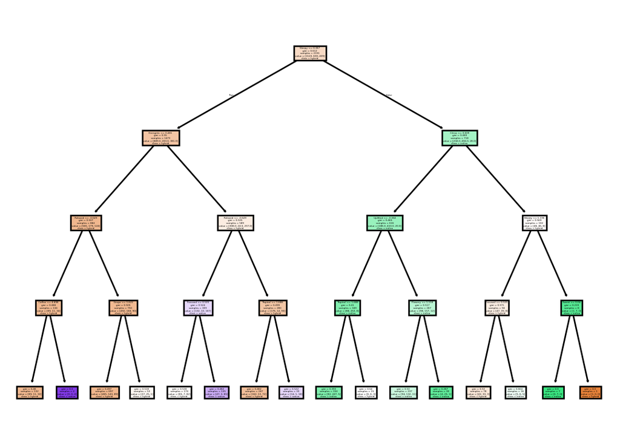

```python
from sklearn.tree import DecisionTreeClassifier, plot_tree
df_multi = df.dropna()
X = df_multi.drop(["Strain", "Type", "Rating", "Effects", "Flavor"], axis=1)
y = df_multi["Type"]

dt_model = Pipeline([
    ("scale", StandardScaler()),
    ("model", DecisionTreeClassifier(random_state=42, max_depth=4))
])

dt_model.fit(X, y)
plot_tree(dt_model.named_steps["model"], feature_names=X.columns, filled=True, class_names=["hybrid", "indica", "sativa"])
```

The tree first splits on Sleepy where strains with Sleepy ≤ 0.367 go left while strains with Sleepy > 0.367 go right. In the second split, on the left branch Energetic becomes the splitting factor where strains with Energetic ≤ 0.481 go left and strains with Energetic > 0.481 go right. On the right branch Citrus becomes the splitting factor where strains with Citrus ≤ 0.609 go left and strains with Citrus > 0.609 go right.

Q2 Repeat the analyses from Part One for LDA, QDA, and KNN.

```python
from sklearn.neighbors import KNeighborsClassifier
lda_model = Pipeline([
    ("scale", StandardScaler()),
    ("model", LinearDiscriminantAnalysis())
])

lda_cv_scores = cross_val_score(lda_model, X, y, cv=5, scoring="accuracy")
lda_model.fit(X, y)
lda_cm = confusion_matrix(y, lda_model.predict(X))

qda_model = Pipeline([
    ("scale", StandardScaler()),
    ("model", QuadraticDiscriminantAnalysis())
])

qda_cv_scores = cross_val_score(qda_model, X, y, cv=5, scoring="accuracy")
qda_model.fit(X, y)
qda_cm = confusion_matrix(y, qda_model.predict(X))

knn_model = Pipeline([
    ("scale", StandardScaler()),
    ("model", KNeighborsClassifier())
])

knn_param_grid = {
    "model__n_neighbors": [3, 5, 7, 9, 11, 15, 20]
}

knn_grid = GridSearchCV(knn_model, knn_param_grid, cv=5, scoring="accuracy")
knn_grid.fit(X, y)
knn_cm = confusion_matrix(y, knn_grid.predict(X))

lda_cm, qda_cm, knn_cm
```

[output not shown]

[output cut: 16 more lines]

[output not shown]

```
(array([[780, 203, 140],
        [188, 461,  10],
        [206,  20, 183]]),
 array([[204,  46, 873],
        [ 97,  55, 507],
        [ 42,  10, 357]]),
 array([[936, 152,  35],
        [324, 332,   3],
        [311,  18,  80]]))
```

Q3 Were your metrics better or worse than in Part One? Why? Which categories were most likely to get mixed up, according to the confusion matrices? Why? Metrics were worse than in Part One. Binary classification, 2 classes, is less complex than multiclass, 3 classes.

Part Three: Multiclass from Binary Consider two models designed for binary classification: SVC and Logistic Regression.

Q1 Fit and report metrics for OvR versions of the models. That is, for each of the two model types, create three models: Indica vs. Not Indica Sativa vs. Not Sativa Hybrid vs. Not Hybrid

```python
from sklearn.linear_model import LogisticRegression
X = df_multi.drop(["Strain", "Type", "Rating", "Effects", "Flavor"], axis=1)
y = df_multi["Type"]
y_indica = (y == "indica") * 1
y_sativa = (y == "sativa") * 1
y_hybrid = (y == "hybrid") * 1

svc_indica_model = Pipeline([
    ("scale", StandardScaler()),
    ("model", SVC())
])
svc_indica_param_grid = {
    "model__C": [0.1, 1, 10, 100],
    "model__gamma": ["scale", "auto", 0.001, 0.01]
}
svc_indica_grid = GridSearchCV(svc_indica_model, svc_indica_param_grid, cv=5, scoring="accuracy")
svc_indica_grid.fit(X, y_indica)
svc_indica_cm = confusion_matrix(y_indica, svc_indica_grid.predict(X))

svc_sativa_model = Pipeline([
    ("scale", StandardScaler()),
    ("model", SVC())
])
svc_sativa_param_grid = {
    "model__C": [0.1, 1, 10, 100],
    "model__gamma": ["scale", "auto", 0.001, 0.01]
}
svc_sativa_grid = GridSearchCV(svc_sativa_model, svc_sativa_param_grid, cv=5, scoring="accuracy")
svc_sativa_grid.fit(X, y_sativa)
svc_sativa_cm = confusion_matrix(y_sativa, svc_sativa_grid.predict(X))

svc_hybrid_model = Pipeline([
    ("scale", StandardScaler()),
    ("model", SVC())
])
svc_hybrid_param_grid = {
    "model__C": [0.1, 1, 10, 100],
    "model__gamma": ["scale", "auto", 0.001, 0.01]
}
svc_hybrid_grid = GridSearchCV(svc_hybrid_model, svc_hybrid_param_grid, cv=5, scoring="accuracy")
svc_hybrid_grid.fit(X, y_hybrid)
svc_hybrid_cm = confusion_matrix(y_hybrid, svc_hybrid_grid.predict(X))

lr_indica_model = Pipeline([
    ("scale", StandardScaler()),
    ("model", LogisticRegression(max_iter=1000))
])
lr_indica_param_grid = {
    "model__C": [0.01, 0.1, 1, 10, 100]
}
lr_indica_grid = GridSearchCV(lr_indica_model, lr_indica_param_grid, cv=5, scoring="accuracy")
lr_indica_grid.fit(X, y_indica)
lr_indica_cm = confusion_matrix(y_indica, lr_indica_grid.predict(X))

lr_sativa_model = Pipeline([
    ("scale", StandardScaler()),
    ("model", LogisticRegression(max_iter=1000))
])
lr_sativa_param_grid = {
    "model__C": [0.01, 0.1, 1, 10, 100]
}
lr_sativa_grid = GridSearchCV(lr_sativa_model, lr_sativa_param_grid, cv=5, scoring="accuracy")
lr_sativa_grid.fit(X, y_sativa)
lr_sativa_cm = confusion_matrix(y_sativa, lr_sativa_grid.predict(X))

lr_hybrid_model = Pipeline([
    ("scale", StandardScaler()),
    ("model", LogisticRegression(max_iter=1000))
])
lr_hybrid_param_grid = {
    "model__C": [0.01, 0.1, 1, 10, 100]
}
lr_hybrid_grid = GridSearchCV(lr_hybrid_model, lr_hybrid_param_grid, cv=5, scoring="accuracy")
lr_hybrid_grid.fit(X, y_hybrid)
lr_hybrid_cm = confusion_matrix(y_hybrid, lr_hybrid_grid.predict(X))

svc_results = pd.DataFrame({
    "comparison": ["Indica vs Not Indica", "Sativa vs Not Sativa", "Hybrid vs Not Hybrid"],
    "cv_accuracy": [svc_indica_grid.best_score_, svc_sativa_grid.best_score_, svc_hybrid_grid.best_score_]
})
lr_results = pd.DataFrame({
    "comparison": ["Indica vs Not Indica", "Sativa vs Not Sativa", "Hybrid vs Not Hybrid"],
    "cv_accuracy": [lr_indica_grid.best_score_, lr_sativa_grid.best_score_, lr_hybrid_grid.best_score_]
})
svc_results, lr_results
```

```
(             comparison  cv_accuracy
 0  Indica vs Not Indica     0.792338
 1  Sativa vs Not Sativa     0.818345
 2  Hybrid vs Not Hybrid     0.625738,
              comparison  cv_accuracy
 0  Indica vs Not Indica     0.792800
 1  Sativa vs Not Sativa     0.826566
 2  Hybrid vs Not Hybrid     0.617072)
```

Q2 Which of the six models did the best job distinguishing the target category from the rest? Which did the worst? Does this make intuitive sense? Logistic Regression: Sativa vs Not Sativa Logistic Regression: Hybrid vs Not Hybrid Yes, because Sativa has effects opposite to Indica and hybrids are genetic crosses between Indica and Sativa so an Indica-dominant hybrid looks like Indica and a Sativa-dominant hybrid looks like Sativa

Q3 Fit and report metrics for OvO versions of the models. That is, for each of the two model types, create three models: Indica vs. Sativa Indica vs. Hybrid Hybrid vs. Sativa

```python
df_indica_sativa = df_multi[(df_multi["Type"] == "indica") | (df_multi["Type"] == "sativa")]
X_indica_sativa = df_indica_sativa.drop(["Strain", "Type", "Rating", "Effects", "Flavor"], axis=1)
y_indica_sativa = df_indica_sativa["Type"]
df_indica_hybrid = df_multi[(df_multi["Type"] == "indica") | (df_multi["Type"] == "hybrid")]
X_indica_hybrid = df_indica_hybrid.drop(["Strain", "Type", "Rating", "Effects", "Flavor"], axis=1)
y_indica_hybrid = df_indica_hybrid["Type"]
df_hybrid_sativa = df_multi[(df_multi["Type"] == "hybrid") | (df_multi["Type"] == "sativa")]
X_hybrid_sativa = df_hybrid_sativa.drop(["Strain", "Type", "Rating", "Effects", "Flavor"], axis=1)
y_hybrid_sativa = df_hybrid_sativa["Type"]

svc_indica_sativa_model = Pipeline([
    ("scale", StandardScaler()),
    ("model", SVC())
])
svc_indica_sativa_param_grid = {
    "model__C": [0.1, 1, 10, 100],
    "model__gamma": ["scale", "auto", 0.001, 0.01]
}
svc_indica_sativa_grid = GridSearchCV(svc_indica_sativa_model, svc_indica_sativa_param_grid, cv=5, scoring="accuracy")
svc_indica_sativa_grid.fit(X_indica_sativa, y_indica_sativa)
svc_indica_sativa_cm = confusion_matrix(y_indica_sativa, svc_indica_sativa_grid.predict(X_indica_sativa))

svc_indica_hybrid_model = Pipeline([
    ("scale", StandardScaler()),
    ("model", SVC())
])
svc_indica_hybrid_param_grid = {
    "model__C": [0.1, 1, 10, 100],
    "model__gamma": ["scale", "auto", 0.001, 0.01]
}
svc_indica_hybrid_grid = GridSearchCV(svc_indica_hybrid_model, svc_indica_hybrid_param_grid, cv=5, scoring="accuracy")
svc_indica_hybrid_grid.fit(X_indica_hybrid, y_indica_hybrid)
svc_indica_hybrid_cm = confusion_matrix(y_indica_hybrid, svc_indica_hybrid_grid.predict(X_indica_hybrid))

svc_hybrid_sativa_model = Pipeline([
    ("scale", StandardScaler()),
    ("model", SVC())
])
svc_hybrid_sativa_param_grid = {
    "model__C": [0.1, 1, 10, 100],
    "model__gamma": ["scale", "auto", 0.001, 0.01]
}
svc_hybrid_sativa_grid = GridSearchCV(svc_hybrid_sativa_model, svc_hybrid_sativa_param_grid, cv=5, scoring="accuracy")
svc_hybrid_sativa_grid.fit(X_hybrid_sativa, y_hybrid_sativa)
svc_hybrid_sativa_cm = confusion_matrix(y_hybrid_sativa, svc_hybrid_sativa_grid.predict(X_hybrid_sativa))

lr_indica_sativa_model = Pipeline([
    ("scale", StandardScaler()),
    ("model", LogisticRegression(max_iter=1000))
])
lr_indica_sativa_param_grid = {
    "model__C": [0.01, 0.1, 1, 10, 100]
}
lr_indica_sativa_grid = GridSearchCV(lr_indica_sativa_model, lr_indica_sativa_param_grid, cv=5, scoring="accuracy")
lr_indica_sativa_grid.fit(X_indica_sativa, y_indica_sativa)
lr_indica_sativa_cm = confusion_matrix(y_indica_sativa, lr_indica_sativa_grid.predict(X_indica_sativa))

lr_indica_hybrid_model = Pipeline([
    ("scale", StandardScaler()),
    ("model", LogisticRegression(max_iter=1000))
])
lr_indica_hybrid_param_grid = {
    "model__C": [0.01, 0.1, 1, 10, 100]
}
lr_indica_hybrid_grid = GridSearchCV(lr_indica_hybrid_model, lr_indica_hybrid_param_grid, cv=5, scoring="accuracy")
lr_indica_hybrid_grid.fit(X_indica_hybrid, y_indica_hybrid)
lr_indica_hybrid_cm = confusion_matrix(y_indica_hybrid, lr_indica_hybrid_grid.predict(X_indica_hybrid))

lr_hybrid_sativa_model = Pipeline([
    ("scale", StandardScaler()),
    ("model", LogisticRegression(max_iter=1000))
])
lr_hybrid_sativa_param_grid = {
    "model__C": [0.01, 0.1, 1, 10, 100]
}
lr_hybrid_sativa_grid = GridSearchCV(lr_hybrid_sativa_model, lr_hybrid_sativa_param_grid, cv=5, scoring="accuracy")
lr_hybrid_sativa_grid.fit(X_hybrid_sativa, y_hybrid_sativa)
lr_hybrid_sativa_cm = confusion_matrix(y_hybrid_sativa, lr_hybrid_sativa_grid.predict(X_hybrid_sativa))

svc_results = pd.DataFrame({
    "comparison": ["Indica vs Sativa", "Indica vs Hybrid", "Hybrid vs Sativa"],
    "cv_accuracy": [svc_indica_sativa_grid.best_score_, svc_indica_hybrid_grid.best_score_, svc_hybrid_sativa_grid.best_score_]
})
lr_results = pd.DataFrame({
    "comparison": ["Indica vs Sativa", "Indica vs Hybrid", "Hybrid vs Sativa"],
    "cv_accuracy": [lr_indica_sativa_grid.best_score_, lr_indica_hybrid_grid.best_score_, lr_hybrid_sativa_grid.best_score_]
})
svc_results, lr_results
```

```
(         comparison  cv_accuracy
 0  Indica vs Sativa     0.853947
 1  Indica vs Hybrid     0.757583
 2  Hybrid vs Sativa     0.748036,
          comparison  cv_accuracy
 0  Indica vs Sativa     0.862362
 1  Indica vs Hybrid     0.749164
 2  Hybrid vs Sativa     0.751306)
```

Q4 Which of the six models did the best job distinguishing at differentiating the two groups? Which did the worst? Does this make intuitive sense? Logistic Regression: Indica vs Sativa SVC: Hybrid vs Sativa Yes, because Indica and Sativa characteristics are mutually exclusive and Sativa-dominant hybrids look very similar to pure Sativas

Q5 Suppose you had simply input the full data, with three classes, into the LogisticRegression function. Would this have automatically taken an “OvO” approach or an “OvR” approach? What about for SVC? OvR OvO